# Diversidade Filogenética

## Aspectos teóricos

A diversidade filogenética captura a ancestralidade compartilhada entre as espécies em termos de quantidade da história evolutiva e o grau de parentesco entre as espécies. Pesquisadores tem utilizado diferentes métricas de diversidade filogenética em duas linhas de investigações principais: i) incorporar a história evolutiva das espécies na seleção das áreas prioritárias para conservação visando minimizar a perda da diversidade evolutiva (Vane-Wright et al. 1991; Faith 1992), e ii) produzir *insigths* sobre os processos atuando na montagem das comunidades (Webb et al. 2002; Helmut et al. 2007). A quantidade de artigos abordando ecologia, macroecologia e conservação com diversidade filogenética cresceram exponencialmente nas últimas décadas. Seguindo esta tendência, o número de métricas de diversidade filogénetica propostas não param de aumentar. Tucker et al. (2016) revisaram 70 métricas de diversidade filogenética e classificaram estas métricas em três dimensões: i) **riqueza** que representa a soma da diferença filogenética acumulada entre táxons; ii) **divergência** que representa a diferença filogenética média entre táxons em uma assembleia; e iii) **regularidade** que representa o quão regular são as diferenças filogenéticas entre táxons em uma assembleia. Outros autores utilizaram diferentes classificações (e.g. Pavoine & Bonsall 2011; Vellend et al. 2011; Garamszeg et al. 2014). Neste capítulo, iremos seguir a classificação de Tucker et al. (2016) e mostrar algumas das principais métricas dentro de cada uma dessas dimensões. Alguns autores recomendam que os pesquisadores não foquem em apenas uma dimensão, mas comparem métricas de diferentes dimensões (Villéger et al. 2008; Tucker et al. 2016)

## Básico sobre manipulação de filogenias

Nesta seção iremos descrever as linhas de comando no R para carregar uma filogenia, plotar a filogenia, acessar os dados da filogenia e excluir e adicionar espécies na filogenia. Estas são linhas de comando introdutórias e necessárias para realizarmos as análises de diversidade filogenética. Não iremos descrever os comandos necessários para construir uma filogenia. Estamos assumindo que já existe uma filogenia disponível para os organismos de interesse.

Carregando o arquivo com a filogenia de 37 espécies de aves endêmicas da mata atlântica. A filogenia foi extraída de Jetz et al. (2012).

```r
library(ape)
library(ecodados)
minha_arvore <- filogenia_aves

# O objeto (minha_arvore) contem o número de espécies, nome das espécies, se a árvore é enraizada e se inclui o comprimento dos ramos.
minha_arvore
```

```
##
## Phylogenetic tree with 37 tips and 35 internal nodes.
##
## Tip labels:
##  Cranioleuca_pallida, Synallaxis_ruficapilla, Phacellodomus_ferrugineigula, Cinclodes_pabsti, Conopophaga_melanops, Herpsilochmus_pileatus, ...
##
## Rooted; includes branch lengths.
```

Agora vamos plotar a filogenia para visualizar as relações entre as espécies.

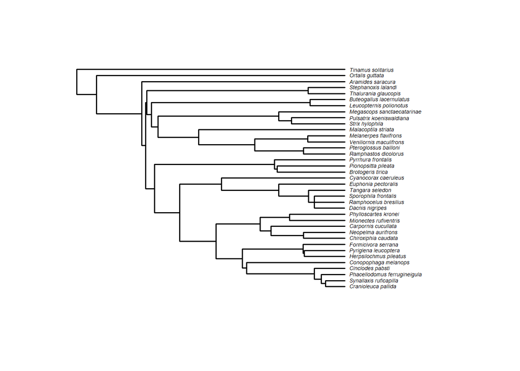

```r
library(phytools)
plot.phylo (minha_arvore, type = "phylogram", show.tip.label = TRUE,
            show.node.label = TRUE, edge.color = "black", edge.width = 1.5,
            tip.color = "black", cex = 0.45, label.offset = 2)
```

Mudando o formato de apresentação da filogenia usando o comando `type` e a cor dos ramos usando o comando `edge.color`.

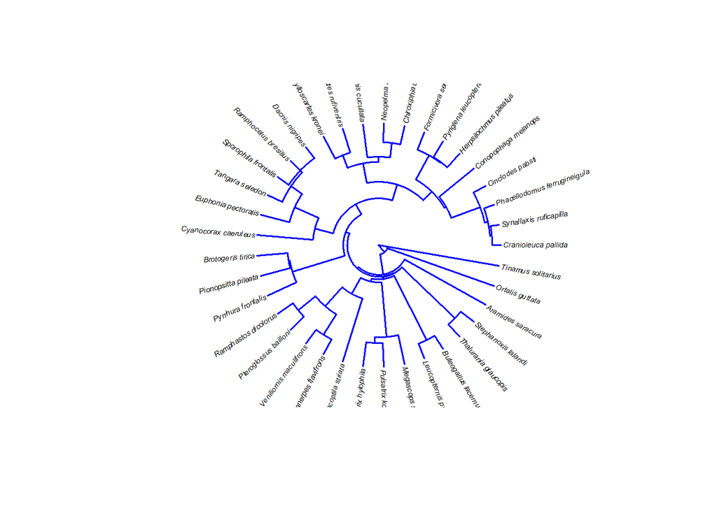

```r
plot.phylo (minha_arvore, type = "fan", show.tip.label = TRUE,
            show.node.label = TRUE, edge.color = "blue", edge.width = 1.5,
            tip.color = "black", cex = 0.45, label.offset = 2)
```

Percebam que existem várias funções para modificar largura e cor dos ramos, tamanho da fonte, distância entre a filogenia e o nomes da espécies e muito mais. Uma sugestão é olharem o blog do professor Liam Revell (http://blog.phytools.org/) que é o criador e mantenedor do pacote *phytools* no R.

Um das características mais interessantes do R é que podemos acessar as informações do objeto. Neste caso, o nosso objeto é a filogenia, e muitas vezes, temos interesse nas informações que estão inseridas dentro da filogenia. Para sabermos quais são as informações que podemos acessar na filogenia, vamos usar o comando `names ()`.

```r
names(minha_arvore)
```

```
## [1] "edge"        "edge.length" "Nnode"       "tip.label"
```

Percebam que temos acesso a quatro componentes da filogenia: i) nó; ii) comprimento do ramo; iii) número de nós; e iv) nome das espécies. Podemos usar o comando `$` para acessar estes componentes. Veja abaixo como acessar o nome das 37 espécies de aves na filogenia.

```r
minha_arvore$tip.label
```

```
##  [1] "Cranioleuca_pallida"          "Synallaxis_ruficapilla"
##  [3] "Phacellodomus_ferrugineigula" "Cinclodes_pabsti"
##  [5] "Conopophaga_melanops"         "Herpsilochmus_pileatus"
##  [7] "Pyriglena_leucoptera"         "Formicivora_serrana"
##  [9] "Chiroxiphia_caudata"          "Neopelma_aurifrons"
## [11] "Carpornis_cucullata"          "Mionectes_rufiventris"
## [13] "Phylloscartes_kronei"         "Dacnis_nigripes"
## [15] "Ramphocelus_bresilius"        "Sporophila_frontalis"
## [17] "Tangara_seledon"              "Euphonia_pectoralis"
## [19] "Cyanocorax_caeruleus"         "Brotogeris_tirica"
## [21] "Pionopsitta_pileata"          "Pyrrhura_frontalis"
## [23] "Ramphastos_dicolorus"         "Pteroglossus_bailloni"
## [25] "Veniliornis_maculifrons"      "Melanerpes_flavifrons"
## [27] "Malacoptila_striata"          "Strix_hylophila"
## [29] "Pulsatrix_koeniswaldiana"     "Megascops_sanctaecatarinae"
## [31] "Leucopternis_polionotus"      "Buteogallus_lacernulatus"
## [33] "Thalurania_glaucopis"         "Stephanoxis_lalandi"
## [35] "Aramides_saracura"            "Ortalis_guttata"
## [37] "Tinamus_solitarius"
```

ou o comprimento de cada um dos ramos da filogenia.

```r
minha_arvore$edge.length
```

```
##  [1]   8.3802647  18.8669712   1.7333865   3.6642170  10.6732942  15.2239228
##  [7]  11.0917270   1.7755983  28.3607791   2.9678911   1.7546545   8.0910030
## [13]   8.0910030   9.8456576  12.8135486  41.1743278  25.4606915   0.5546030
## [19]  16.9346316  16.9346316  17.4892346  18.4363079   4.6581580  13.5498048
## [25]  17.3960309  17.3960309  30.9471871  12.4567724  23.1472214  23.1472214
## [31]  17.4065182  24.1723764  12.4712971   2.4600303  12.6082491  12.5529673
## [37]  12.6146793  15.2153841  27.6866812  51.8590576  50.4721698   1.0975337
## [43]  28.3691666  28.3691666  29.4667004   0.4805624   1.9967144   2.7687118
## [49]  17.0272986  23.4955884  20.5338341  17.3003772  17.3003772  22.2636579
## [55]  15.5705534  15.5705534  61.3297997  50.6621138   5.3479249  22.3470597
## [61]  22.3470597  27.6949846  66.5513507  14.5744595  14.5744595  67.7448719
## [67]  15.3776527  15.3776527  85.3364736 104.2034448 112.5837095
```

Nas análises de diversidade filogenética, as espécies que estarão presentes na filogenia normalmente são aquelas que foram amostradas no seu projeto. Contudo, muitas vezes utilizamos filogenias contendo espécies que não estão presentes no nosso estudo. Neste caso, precisamos excluir essas espécies da filogenia. O comando `drop.tip ()` faz essa tarefa.

```r
# Vamos criar um novo nome para o objeto e excluir as espécies Leucopternis polionotus e Aramides saracura da filogenia
filogenia_cortada <- drop.tip(minha_arvore, c("Leucopternis_polionotus",
                                              "Aramides_saracura"))

filogenia_cortada
```

```
##
## Phylogenetic tree with 35 tips and 33 internal nodes.
##
## Tip labels:
##  Cranioleuca_pallida, Synallaxis_ruficapilla, Phacellodomus_ferrugineigula, Cinclodes_pabsti, Conopophaga_melanops, Herpsilochmus_pileatus, ...
##
## Rooted; includes branch lengths.
```

Vejam que agora a filogenia tem 35 espécies de aves. As duas espécies que selecionamos foram excluídas da filogenia.

Outra situação bem comum é quando precisamos inserir espécies que foram amostradas no nosso estudo, mas não estão presente na filogenia. O comando `add.species.to.genus ()` faz essa tarefa.

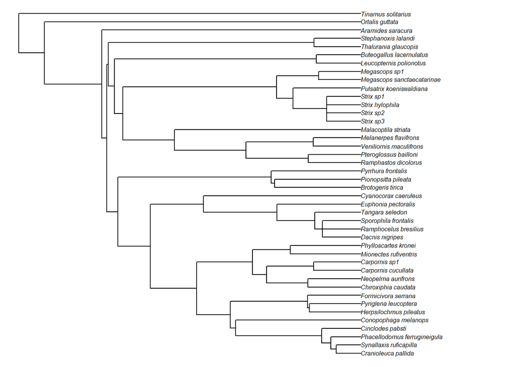

```r
# Vamos inserir as espécies Megascops_sp1, Carponis_sp, Strix_sp1, Strix_sp2 e Strix_sp3 na filogenia
Megascops <- c("Megascops_sp1")
Carpornis <- c("Carpornis_sp1")
Strix <- c("Strix_sp1", "Strix_sp2", "Strix_sp3")

filogenia_nova <- add.species.to.genus(force.ultrametric(minha_arvore), Megascops)
filogenia_nova <- add.species.to.genus(force.ultrametric(filogenia_nova), Carpornis)
# Para inserir mais de uma espécie dentro do gênero, vamos utilizar um loop.
for(i in 1:length(Strix))
filogenia_nova <- add.species.to.genus(force.ultrametric(filogenia_nova),
                                       Strix[i], where="root")

plot(filogenia_nova, cex = 0.5, no.margin = TRUE)
```

## Sinal filogenético

Sinal filogenético é um padrão que pode ser definido como a tendência de espécies aparentadas serem mais fenotipicamente semelhantes entre si do que entre espécies amostradas aleatoriamente na filogenia (Blomberg & Garland 2002).

## Métricas de diversidade alfa filogenética

Métricas de diversidade alfa (⍺) utilizam os dados de presença e ausência ou abundância das espécies para determinar um valor de diversidade para cada comunidade ou sítio de interesse.

#### Exemplo prático 1 - Medidas de diversidade filogenética

**Explicação dos dados**

Neste exemplo avaliaremos a diversidade filogenética de 10 comunidades de aves amostradas ao longo de um gradiente de precipitação. Utilizaremos este conjunto de dados para todos os exemplos das métricas de diversidade filogenética.

**Pergunta:**

> A distribuição dos valores de diversidade filogenética das comunidades está associada com o gradiente de precipitação?

**Predições**

> Os valores de diversidade filogenética serão maiores nas comunidades localizadas em regiões com altas precipitações do que em regiões mais secas.

**Variáveis**

- Variáveis preditoras
  - Dataframe com as comunidades (unidade amostral) nas linhas e as espécies de aves nas colunas.
  - Dataframe com as comunidades (unidade amostral) nas linhas e a variável precipitação anual na coluna
  - Arquivo com a filogenia das 37 espécies de aves

**Checklist**

- Verificar se os dataframes de composição de espécies e variáveis ambientais estão com as unidades amostrais nas linhas e variáveis preditores nas colunas
- Verificar se as comunidades nos dataframes de composição de espécies e variáveis ambientais estão distruídos na mesma sequencia/ordem nos dois arquivos.
- Verificar se o nome das espécies de aves no dataframe de composição de espécies é idêntico ao nome das espécies na filogenia

### Análise da dimensão divergência da diversidade alfa filogenética

As métricas de divergência utilizam a média da distribuição das unidades extraídas da árvore filogenética (Tucker et al. 2016).

#### Mean Pairwise Distance (MPD, Webb et al. 2002)

Esta métrica utiliza a matriz de distância filogenética para quantificar a média total do parentesco entre pares de espécies em uma comunidade. Este índice pode ser calculado considerando dados de presença e ausência ou considerando dados de abundância das espécies. Importante, o MPD é uma métrica basal que pesa a estrutura interna da filogenia (e.g. relações entre espécies de famílias diferentes).

Abaixo demonstramos os comandos no R para o cálculo do MPD utilizando os dados das comunidades de aves.

```r
# Carregando o dataframe com a composição de espécies de aves nas comunidades e a filogenia com as 37 espécies. Estão na pacote ecodados. Caso ainda não tenha carregado o pacote irá precisar carrega-lo aqui.
composicao_especies <- composicao_aves_filogenetica
filogenia_aves <- filogenia_aves

# Confere se há nomes das espécies de aves no dataframe de composição que não estão na filogenia - zero é que os nomes estão corretos. Caso contrário, arrumar.
setdiff(colnames(composicao_especies), filogenia_aves$tip.label)
```

```
## character(0)
```

Os nomes das espécies que estão na planilha são iguais aos nomes que estão na filogenia. Vamos ver o contrário.

```r
# Confere se há nomes das espécies na filogenia que não estão no dataframe de composição - zero é que os nomes estão corretos. Caso contrário, arrumar.
setdiff(filogenia_aves$tip.label, colnames(composicao_especies))
```

```
## character(0)
```

Os nomes das espécies são os mesmo. Podemos continuar as análises.

```r
# Pacote com a função para calcular o MPD
library(picante)

# Análise com dados de presença e ausência das espécies nas comunidades
resultados_MPD_PA <- mpd(composicao_especies, cophenetic(filogenia_aves),
                         abundance.weighted = FALSE)
resultados_MPD_PA # mostra os valores de MPD para cada comunidade
```

```
##  [1] 150.7914 157.3158 146.1622 154.5005 143.0727 141.1926 154.3145 141.4292
##  [9] 139.6198 143.0862
```

Vamos refazer a análise do MPD, mas desta vez, considerando a abundância das espécies de aves nas comunidades.

```r
# Análise com dados de abundância das espécies nas comunidades
resultados_MPD_AB <- mpd(composicao_especies, cophenetic(filogenia_aves),
                         abundance.weighted = TRUE)
resultados_MPD_AB # mostra os valores de MPD para cada comunidade
```

```
##  [1] 135.0704 143.3156 129.1940 142.8127 131.4027 128.7733 134.0380 132.6389
##  [9] 133.4041 117.8787
```

#### Mean Nearest Taxon Distance (MNTD, Webb et al. 2002)

Esta métrica utiliza a matriz de distância filogenética para quantificar a média dos valores mínimos de parentesco entre pares de espécies em uma comunidade. Este índice pode ser calculado considerando dados de presença e ausência ou considerando dados de abundância das espécies. Diferente do MPD , o MNTD é uma métrica terminal que pesa as relações nas pontas da filogenia (e.g. espécies dentro do mesmo gênero).

Abaixo demonstramos os comandos no R para o cálculo do MNTD utilizando os dados das comunidades de aves.

```r
# Dados já foram carregados no exemplo do MPD
# Pacote com a função para calcular o MNTD
library(picante)

# Análise com dados de presença e ausência das espécies nas comunidades
resultados_MNTD_PA <- mntd(composicao_especies, cophenetic(filogenia_aves),
                         abundance.weighted = FALSE)
resultados_MNTD_PA # mostra os valores de MPD para cada comunidade
```

```
##  [1]  63.89727  66.15828  72.96912  67.67170  64.93477  63.72337  93.54980
##  [8]  78.24876  62.34565 112.23127
```

Vamos refazer a análise do MNTD, mas desta vez, considerando a abundância das espécies de aves nas comunidades.

```r
# Análise com dados de abundância das espécies nas comunidades
resultados_MNTD_AB <- mntd(composicao_especies, cophenetic(filogenia_aves),
                         abundance.weighted = TRUE)
resultados_MNTD_AB # mostra os valores de MPD para cada comunidade
```

```
##  [1]  57.11745  53.02212  70.47864  59.12049  61.23225  60.26180 110.13043
##  [8]  97.35404  82.12099 127.70084
```

#### Phylogenetic Species Variability (PSV, Helmut et al. 2007)

Esta métrica quantifica como a relação de parentesco filogenético diminiu a variância de um atributo hipotético (não amostrado) que é compartilhado por todas as espécies na comunidade. Quando todas as espécies em uma amostra não são aparentadas (i.e. filogenia em estrela) , o valor do PSV é 1 (um), indicando máxima variabilidade. Quando as espécies tornando-se mais aparentadas, o valor de PSV aproxima-se de 0 (zero), indicando reduzida variabilidade. Os valores esperados de PSV são estatisticamente independentes da riqueza de espécies. Importante, os valores de PSV são identicos ao MPD quando a filogenia é ultramétrica.

Abaixo demonstramos os comandos no R para o cálculo do PSV utilizando os dados das comunidades de aves.

```r
# Dados já foram carregados no exemplo do MPD
# Pacote com a função para calcular o PSV
library(picante)

# Análise com dados de presença e ausência das espécies nas comunidades
resultados_PSV <- psv(composicao_especies,filogenia_aves)
resultados_PSV # mostra os valores de MPD para cada comunidade
```

```
##             PSVs SR         vars
## Com_1  0.6697865 27 6.224834e-05
## Com_2  0.6987378 26 7.221499e-05
## Com_3  0.6492375 25 8.329332e-05
## Com_4  0.6861589 25 8.329332e-05
## Com_5  0.6355271 22 1.252245e-04
## Com_6  0.6270572 18 2.140033e-04
## Com_7  0.6853322 15 3.288296e-04
## Com_8  0.6281778 12 5.361887e-04
## Com_9  0.6200717 13 4.513324e-04
## Com_10 0.6355626  9 9.812931e-04
```

### Análise da dimensão riqueza da diversidade alfa filogenética

As métricas de riqueza somam a quantidade da diferença filogenética presente em uma comunidade (Tucker et al. 2016).

#### Phylogenetic diversity (PD, Faith 1992)

Esta métrica é definda pela soma do comprimento dos ramos conectando todas as espécies. Abaixo demonstramos os comandos no R para o cálculo de PD para as comunidades de aves.

```r
# Dados já foram carregados no exemplo do MPD
# Calculando a métrica de diversidade filogenética proposta por Faith (1992)
library(picante)

resultados_PD <- pd(composicao_especies, filogenia_aves)
head(resultados_PD) # mostra o valor de PD e riqueza de espécies para cada comunidade
```

```
##             PD SR
## Com_1 1259.315 27
## Com_2 1293.152 26
## Com_3 1222.310 25
## Com_4 1254.541 25
## Com_5 1021.967 22
## Com_6  856.781 18
```

#### Phylogenetic Species Richness (PSR, Helmut et al. 2007)

Esta métrica é calculada multiplicando a riqueza de espécies registrada na comunidade pelo PSV da comunidade. PSR é diretamente comparável ao número de espécies na comunidade, mas inclui o parestenco filogenético entre as espécies.

Abaixo demonstramos os comandos no R para o cálculo do PSR utilizando os dados das comunidades de aves.

```r
# Dados já foram carregados no exemplo do MPD
# Pacote com a função para calcular o PSR
library(picante)

# Análise com dados de composição das espécies nas comunidades
resultados_PSR <- psr(composicao_especies,filogenia_aves)
resultados_PSR # mostra os valores de PSR para cada comunidade
```

```
##              PSR SR       vars
## Com_1  18.084236 27 0.04537904
## Com_2  18.167183 26 0.04881734
## Com_3  16.230938 25 0.05205832
## Com_4  17.153972 25 0.05205832
## Com_5  13.981597 22 0.06060866
## Com_6  11.287030 18 0.06933707
## Com_7  10.279983 15 0.07398666
## Com_8   7.538134 12 0.07721118
## Com_9   8.060933 13 0.07627517
## Com_10  5.720063  9 0.07948474
```

#### Phylogenetic Endemism (PE, Rosauer et al. 2009)

Esta métrica calcula a fração dos ramos restritas a regiões específicas. PE reflete a singularidade espacial dos ramos da filogenia. PE é uma métrica proposta para auxiliar estudos de conservação estabelecendo critérios para priorizar regiões a serem conservadas com base na importância evolutiva das espécies que ocorrem nestes locais.

Abaixo demonstramos os comandos no R para o cálculo do PE utilizando os dados das comunidades de aves.

```r
# Dados já foram carregados no exemplo do MPD
# Pacote com a função para calcular PE
library(phyloregion)

# transformando data.frame em matriz
dados_matriz <- as.matrix(composicao_especies)

# Análise
resultados_PE <- phylo_endemism(dados_matriz, filogenia_aves,
                               weighted = TRUE)
resultados_PE # mostra os valores de PE para cada comunidade
```

```
##     Com_1     Com_2     Com_3     Com_4     Com_5     Com_6     Com_7     Com_8
## 232.09145 272.60106 210.22647 218.89037 146.99281 135.06423 148.65234  79.22402
##     Com_9    Com_10
##  77.95458  68.50266
```

#### Species Evolutionary Distinctiveness (ED, Redding & Mooers 2006)

Esta métrica calcula qual é a fração da árvore filogenética que é atribuída para uma espécie. ED reflete quão evolutivamente isolada uma espécie é comparada com as outras espécies na filogenia. ED é uma métrica proposta para auxiliar estudos de conservação estabelecendo critérios para priorizar as espécies a serem conservadas com base na sua importância evolutiva. Portanto, apenas as informações da filogenia são utilizadas para o calculo de ED.

Abaixo demonstramos os comandos no R para o cálculo do ED utilizando os dados das comunidades de aves.

```r
# Dados já foram carregados no exemplo do MPD
# Pacote com a função para calcular ED
library(picante)

# Análise
resultados_ED <- evol.distinct(filogenia_aves)
resultados_ED # mostra os valores de ED para cada espécie
```

```
##                         Species         w
## 1           Cranioleuca_pallida  14.07447
## 2        Synallaxis_ruficapilla  14.07447
## 3  Phacellodomus_ferrugineigula  20.05793
## 4              Cinclodes_pabsti  30.27020
## 5          Conopophaga_melanops  47.72685
## 6        Herpsilochmus_pileatus  26.40947
## 7          Pyriglena_leucoptera  26.40947
## 8           Formicivora_serrana  35.88431
## 9           Chiroxiphia_caudata  29.08591
## 10           Neopelma_aurifrons  29.08591
## 11          Carpornis_cucullata  40.77714
## 12        Mionectes_rufiventris  36.87648
## 13         Phylloscartes_kronei  36.87648
## 14              Dacnis_nigripes  21.55995
```

[output cut: 23 more lines]

### Análise da dimensão regularidade da diversidade alfa filogenética

As métricas de regularidade caracterizam como uma árvore filogenética difere de uma filogenia em estrela (i.e. uma filogenia na qual as espécies são igualmente não relacionadas; Tucker et al. 2016).

#### Variance of Pairwise Distance (VPD, Clarke & Warwick 2001)

Esta métrica utiliza a matriz de distância filogenética para quantificar a variância do parentesco entre pares de espécies em uma comunidade.

Abaixo demonstramos os comandos no R para o cálculo do VPD utilizando os dados das comunidades de aves.

```r
# Dados já foram carregados no exemplo do MPD
# Pacote com a função para calcular VPD
library(pez)

# transformando data.frame em matriz
dados_matriz <- as.matrix(composicao_especies)

# transformar os dados para o formato requerido pelo pacote pez
dados <- comparative.comm (filogenia_aves, dados_matriz)

# Análise
resultados_VPD <- .vpd(dados, cophenetic(filogenia_aves))
resultados_VPD # mostra os valores de VPD para cada comunidade
```

```
##     Com_1    Com_10     Com_2     Com_3     Com_4     Com_5     Com_6     Com_7
## 1619.4697 1031.8887 1828.1930 1630.4026 1317.9919 1465.1728 1519.6115  825.5349
##     Com_8     Com_9
## 1278.0076 1508.0495
```

#### Correlação entre as métricas de diversidade alfa filogenética

Vamos avaliar a correlação entre os valores das métricas de diversidade alfa filogenética

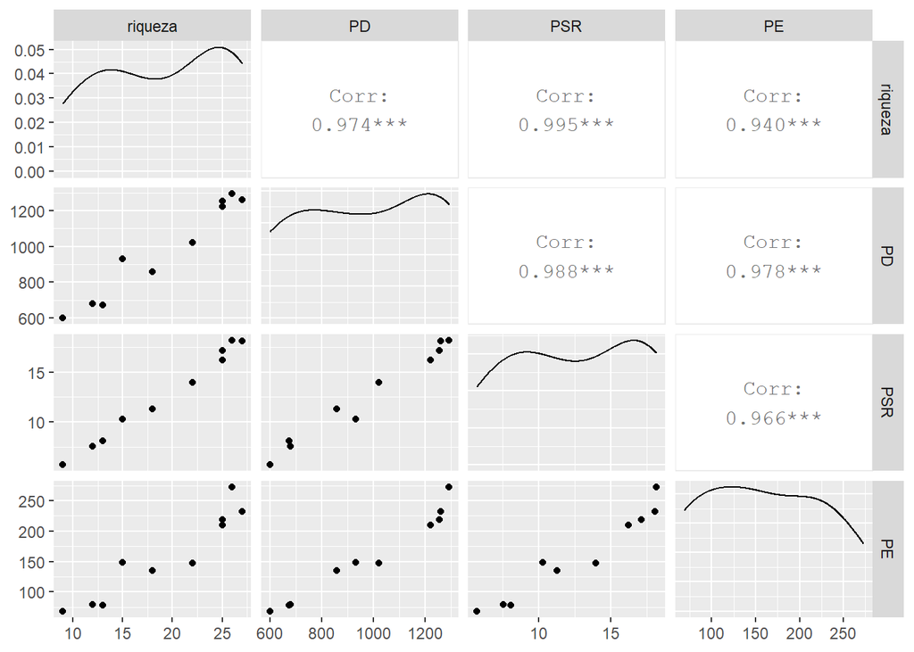

```r
# Vamos criar um data.frame com os resultados das métricas separados para as dimensões de riqueza e divergência. Não iremos fazer para regularidade pois só apresentamos uma métrica de diversidade filogenética nesta dimensão.

metricas_riqueza <- data.frame(riqueza = resultados_PD$SR,
                       PD = resultados_PD$PD,
                       PSR = resultados_PSR$PSR,
                       PE = resultados_PE)

# gráfico
library(GGally)
ggpairs(metricas_riqueza, upper=list(continuous = wrap("cor", size = 4)))
```

Percebam que as três métricas apresentam entre elas correlações acima de 96%. Isso indica que as métricas são redundantes. Portanto, não há necessidade de calcular mais de uma métrica dentro da dimensão da riqueza filogenética. Percebem que as três métricas de diversidade alfa filogenética também apresentam alta correlação com a riqueza de espécies. Veja a seção de modelos nulos que controla o efeito da riqueza de espécies nas métricas de diversidade filogenética.

Vamos avaliar a correlação entre os valores das métricas de diversidade alfa filogénetica para a dimensão divergência.

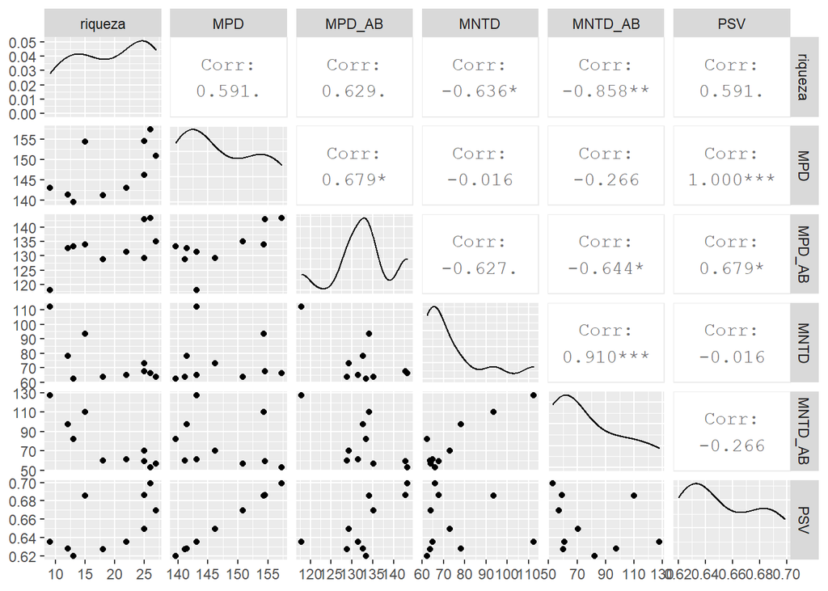

```r
# Vamos criar um data.frame com os resultados das métricas da dimensão divergência.

metricas_divergencia <- data.frame(riqueza = resultados_PD$SR,
                       MPD = resultados_MPD_PA,
                       MPD_AB = resultados_MPD_AB,
                       MNTD = resultados_MNTD_PA,
                       MNTD_AB = resultados_MNTD_AB,
                       PSV = resultados_PSV$PSVs)

# Gráfico
library(GGally)
ggpairs(metricas_divergencia, upper=list(continuous = wrap("cor", size = 4)))
```

Como mencionado, as métricas MPD e PSV são identicas quando usamos uma filogenia ultramétrica. Contudo, as métricas de divergência não apresentam correlações tão altas como as métricas da dimensão riqueza. Além disso, estas métricas não são tão afetadas pela riqueza de espécies das comunidades como as métricas da dimensão riqueza.

#### Associação entre as métricas de diversidade alfa filogenética e o gradiente de precipitação

Vamos avaliar e plotar a relação entre os valores de algumas métrica de diversidade alfa filogenética (variável resposta) e os valores de precipitação (variável preditora).

#### Gráficos das métricas da dimensão divergência da diversidade alfa filogenética

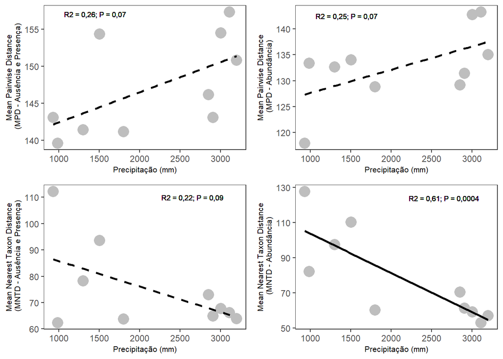

```r
# Vamos carregar a planilha com os dados de precipitação para cada comunidade. Estes dados estão no pacote ecodados já carregado no início do capítulo.
precipitacao <- precipitacao_filogenetica

# Vamos inserir os dados de precipitação na planilha metrica_divergencia
metricas_divergencia$precipitacao <- precipitacao$prec

# Gráficos
library(ggplot2)
library(ggpubr)
MPD_PA_plot <- ggplot(metricas_divergencia, aes(precipitacao, MPD)) +
        labs(x = "Precipitação (mm)",
             y = "Mean Pairwise Distance\n (MPD - Ausência e Presença)") +
        geom_point(size = 5, shape = 19, col = "gray") +
        theme_bw() +
        theme(panel.grid.major = element_blank(),
              panel.grid.minor = element_blank(),
              axis.title.y = element_text(size = 8),
               axis.title.x = element_text(size = 8)) +
        geom_smooth(method = lm, se = FALSE, color = "black", linetype="dashed") +
        geom_text(x = 1450, y = 157, label = "R2 = 0,26; P = 0,07",
                  color = "black", size = 2.5)
MPD_AB_plot <- ggplot(metricas_divergencia, aes(precipitacao, MPD_AB)) +
        labs(x = "Precipitação (mm)",
             y = "Mean Pairwise Distance\n (MPD - Abundância)", size = 8) +
        geom_point(size = 5, shape = 19, col = "gray") +
        theme_bw() +
        theme(panel.grid.major = element_blank(),
              panel.grid.minor = element_blank(),
              axis.title.y = element_text(size = 8),
              axis.title.x = element_text(size = 8)) +
        geom_smooth(method = lm, se = FALSE, color = "black", linetype="dashed") +
        geom_text(x = 1450, y = 142.5, label = "R2 = 0,25; P = 0,07",
                  color = "black", size = 2.5)
MNTD_AP_plot <- ggplot(metricas_divergencia, aes(precipitacao, MNTD)) +
        labs(x = "Precipitação (mm)",
             y = "Mean Nearest Taxon Distance\n (MNTD - Ausência e Presença)",
             size = 8) +
        geom_point(size = 5, shape = 19, col = "gray") +
        theme_bw() +
        theme(panel.grid.major = element_blank(),
              panel.grid.minor = element_blank(),
              axis.title.y = element_text(size = 8),
              axis.title.x = element_text(size = 8)) +
        geom_smooth(method = lm, se = FALSE, color = "black", linetype="dashed") +
        geom_text(x = 2650, y = 110, label = "R2 = 0,22; P = 0,09",
                  color = "black", size = 2.5)
MNTD_AB_plot <- ggplot(metricas_divergencia, aes(precipitacao, MNTD_AB)) +
        labs(x = "Precipitação (mm)",
             y = "Mean Nearest Taxon Distance\n (MNTD - Abundância)",
             size = 8) +
        geom_point(size = 5, shape = 19, col = "gray") +
        theme_bw() +
        theme(panel.grid.major = element_blank(),
              panel.grid.minor = element_blank(),
              axis.title.y = element_text(size = 8),
              axis.title.x = element_text(size = 8)) +
        geom_smooth(method = lm, se = FALSE, color = "black") +
        geom_text(x = 2650, y = 124, label = "R2 = 0,61; P = 0,0004",
                  color = "black", size = 2.5)
ggarrange(MPD_PA_plot, MPD_AB_plot, MNTD_AP_plot, MNTD_AB_plot, nrow = 2, ncol = 2)
```

O MPD que avalia as relações de parentesco mais internas da filogenia (i.e. relações entre espécies de famílias diferentes) não apresentou associação com o gradiente de precipitação. Por outro lado, o MNTD que avalia as relações mais terminais da filogenia (i.e. espécies dentro do mesmo gênero) apresentou uma relação negativa com o gradiente de precipitação. Contudo, esta associação só foi significativa quando pesamos a análise pela abundância das espécies nas comunidades.

#### Gráficos das métricas da dimensão riqueza da diversidade alfa filogenética

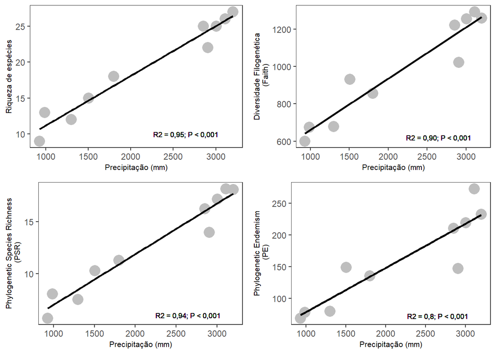

```r
# Vamos inserir os dados de precipitação na planilha metrica_riqueza
metricas_riqueza$precipitacao <- precipitacao$prec

# Gráficos
library(ggplot2)
library(ggpubr)
Riqueza_plot <- ggplot(metricas_riqueza, aes(precipitacao, riqueza)) +
        labs(x = "Precipitação (mm)",
             y = "Riqueza de espécies") +
        geom_point(size = 5, shape = 19, col = "gray") +
        theme_bw() +
        theme(panel.grid.major = element_blank(),
              panel.grid.minor = element_blank(),
              axis.title.y = element_text(size = 8),
               axis.title.x = element_text(size = 8)) +
        geom_smooth(method = lm, se = FALSE, color = "black") +
        geom_text(x = 2650, y = 10, label = "R2 = 0,95; P < 0,001",
                  color = "black", size = 2.5)
PD_plot <- ggplot(metricas_riqueza, aes(precipitacao, PD)) +
        labs(x = "Precipitação (mm)",
             y = "Diversidade Filogenética\n (Faith)", size = 8) +
        geom_point(size = 5, shape = 19, col = "gray") +
        theme_bw() +
        theme(panel.grid.major = element_blank(),
              panel.grid.minor = element_blank(),
              axis.title.y = element_text(size = 8),
              axis.title.x = element_text(size = 8)) +
        geom_smooth(method = lm, se = FALSE, color = "black") +
        geom_text(x = 2650, y = 620, label = "R2 = 0,90; P < 0,001",
                  color = "black", size = 2.5)
PSR_plot <- ggplot(metricas_riqueza, aes(precipitacao, PSR)) +
        labs(x = "Precipitação (mm)",
             y = "Phylogenetic Species Richness\n (PSR)",
             size = 8) +
        geom_point(size = 5, shape = 19, col = "gray") +
        theme_bw() +
        theme(panel.grid.major = element_blank(),
              panel.grid.minor = element_blank(),
              axis.title.y = element_text(size = 8),
              axis.title.x = element_text(size = 8)) +
        geom_smooth(method = lm, se = FALSE, color = "black") +
        geom_text(x = 2650, y = 6, label = "R2 = 0,94; P < 0,001",
                  color = "black", size = 2.5)
PE_plot <- ggplot(metricas_riqueza, aes(precipitacao, PE)) +
        labs(x = "Precipitação (mm)",
             y = "Phylogenetic Endemism\n (PE)",
             size = 8) +
        geom_point(size = 5, shape = 19, col = "gray") +
        theme_bw() +
        theme(panel.grid.major = element_blank(),
              panel.grid.minor = element_blank(),
              axis.title.y = element_text(size = 8),
              axis.title.x = element_text(size = 8)) +
        geom_smooth(method = lm, se = FALSE, color = "black") +
        geom_text(x = 2650, y = 72, label = "R2 = 0,8; P < 0,001",
                  color = "black", size = 2.5)
ggarrange(Riqueza_plot, PD_plot, PSR_plot, PE_plot, nrow = 2, ncol = 2)
```

As três métricas de diversidade filogenética foram relacionadas com o gradiente de precipitação. Comunidades localizadas em áreas com maior precipitação anual abrigaram maior diversidade filogenética do que comunidades localizadas em áreas mais secas. Contudo, estas métricas são dependentes da riqueza de espécies nas comunidades. Veja a seção de modelos nulos para entender como lidar com essa dependência.

## Métricas de diversidade beta filogenética

Métricas de diversidade beta filogenética utilizam dados de presença e ausência ou abundância das espécies para determinar um valor que representa a diferença entre comunidades em relação a história evolutiva das linhagens.

### Análise da dimensão divergência da diversidade beta filogenética

#### Community Mean Pairwise Distance (COMDIST, Webb et al. 2008)

Esta métrica é uma extensão do MPD. COMDIST calcula a média da distância filogenética entre as espécies de duas comunidades. COMDIST pode ser calculada usando dados de presença e ausência ou abundância das espécies. Está extensão do MPD também é conhecida na literatura como Dpw (Swenson 2011) .

Abaixo demonstramos os comandos no R para o cálculo do COMDIST utilizando os dados das comunidades de aves.

```r
# Dados já foram carregados no exemplo do MPD
# Pacote com a função para calcular o COMDIST
library(picante)

# Análise com dados de presença e ausência das espécies nas comunidades
resultados_Comdist_PA <- comdist(composicao_especies,
                                 cophenetic(filogenia_aves),
                                 abundance.weighted = FALSE)
resultados_Comdist_PA # mostra uma matriz triangular com a média da distância filogenética entre as espécies das duas comunidades
```

```
##           Com_1    Com_2    Com_3    Com_4    Com_5    Com_6    Com_7    Com_8
## Com_2  150.5242
## Com_3  144.3300 148.7436
## Com_4  149.4782 153.2992 147.5838
## Com_5  141.8435 146.9829 139.9606 145.8746
## Com_6  142.6019 148.3160 140.0376 143.1340 137.9527
## Com_7  147.7189 150.2248 147.1703 150.3418 144.1481 145.2975
## Com_8  141.3083 145.6684 138.5875 145.3897 137.0034 137.7062 144.4818
## Com_9  141.6018 146.4697 138.3515 144.3480 136.9036 136.3453 144.3257 130.7628
## Com_10 140.8810 145.9333 136.9978 145.1400 136.5394 137.2350 144.3660 130.0691
##           Com_9
## Com_2
## Com_3
## Com_4
## Com_5
## Com_6
## Com_7
## Com_8
## Com_9
## Com_10 130.2321
```

Vamos refazer a análise do COMDIST, mas desta vez, considerando a abundância das espécies de aves nas comunidades.

```r
# Análise com dados de abundância das espécies nas comunidades
resultados_Comdist_AB <- comdist(composicao_especies,
                                 cophenetic(filogenia_aves),
                                 abundance.weighted = TRUE)
resultados_Comdist_AB # mostra uma matriz triangular com a média da distância filogenética entre as espécies das duas comunidades
```

```
##           Com_1    Com_2    Com_3    Com_4    Com_5    Com_6    Com_7    Com_8
## Com_2  144.9367
## Com_3  136.3265 143.3381
## Com_4  143.8360 150.1510 140.2446
## Com_5  135.3787 143.8408 134.1859 142.5311
## Com_6  137.6786 144.8361 133.2373 141.2769 133.8588
## Com_7  144.6532 150.6215 143.7062 145.9607 142.3332 143.7716
## Com_8  143.7467 150.8984 140.4987 148.4035 142.6185 144.4832 143.9244
## Com_9  145.4972 152.7698 141.6234 147.0325 144.5540 145.6658 139.1639 135.3074
## Com_10 147.8617 155.8546 144.3385 150.2865 146.3211 148.7162 142.4861 130.0058
##           Com_9
## Com_2
## Com_3
## Com_4
## Com_5
## Com_6
## Com_7
## Com_8
## Com_9
## Com_10 132.0343
```

#### Community Mean Nearest Taxon Distance (COMDISTNT, Webb et al. 2008)

Esta métrica é uma extensão do MNTD. COMDISTNT calcula a média da distância filogenética entre o táxon mais próximo das espécies de duas comunidades. COMDISTNT pode ser calculada usando dados de presença e ausência ou abundância das espécies. Está extensão do MNTD também é conhecida na literatura como Dnn (Swenson 2011) .

Abaixo demonstramos os comandos no R para o cálculo do COMDISTNT utilizando os dados das comunidades de aves.

```r
# Dados já foram carregados no exemplo do MPD
# Pacote com a função para calcular o COMDISTNT
library(picante)

# Análise com dados de presença e ausência das espécies nas comunidades
resultados_Comdistnt_PA <- comdistnt(composicao_especies,
                                     cophenetic(filogenia_aves),
                                     abundance.weighted = FALSE)
resultados_Comdistnt_PA # mostra uma matriz triangular com a média da distância filogenética entre o táxon mais próximo das espécies das duas comunidades
```

```
##           Com_1    Com_2    Com_3    Com_4    Com_5    Com_6    Com_7    Com_8
## Com_2  24.65946
## Com_3  18.56953 22.22310
## Com_4  26.85806 24.04505 17.87073
## Com_5  13.15074 34.14223 18.82684 25.54000
## Com_6  35.43332 49.33726 33.82511 24.59980 28.50505
## Com_7  30.37968 29.22411 39.89649 34.06858 29.27588 47.69536
## Com_8  38.16628 48.17376 38.46830 51.02029 32.52846 50.37593 54.37647
## Com_9  42.58727 54.09441 41.83792 46.29635 36.35245 46.18264 49.85495 10.69759
## Com_10 45.71452 56.82713 40.39642 60.17935 40.74857 59.63770 60.24556 10.87162
##           Com_9
## Com_2
## Com_3
## Com_4
## Com_5
## Com_6
## Com_7
## Com_8
## Com_9
## Com_10 16.12367
```

Vamos refazer a análise do COMDISTNT, mas desta vez, considerando a abundância das espécies de aves nas comunidades.

```r
# Análise com dados de abundância das espécies nas comunidades
resultados_Comdistnt_AB <- comdistnt(composicao_especies,
                                     cophenetic(filogenia_aves),
                                     abundance.weighted = TRUE)
resultados_Comdistnt_AB # mostra uma matriz triangular com a média da distância filogenética entre o táxon mais próximo das espécies das duas comunidades
```

```
##            Com_1     Com_2     Com_3     Com_4     Com_5     Com_6     Com_7
## Com_2  30.979521
## Com_3  14.921355 21.021646
## Com_4  22.436649 26.103247  9.159768
## Com_5   6.856716 39.216294 18.227289 22.048474
## Com_6  28.134510 38.679559 23.812572 16.345786 21.856888
## Com_7  20.046444 22.268966 30.014949 26.539680 20.084622 47.737669
## Com_8  24.444444 41.680367 25.210588 35.082819 30.632382 62.650144 38.947065
## Com_9  28.900764 46.524663 24.660772 29.379583 32.458809 61.970450 23.396238
## Com_10 29.755440 47.876854 24.078539 34.501669 35.195663 82.627324 44.080869
##            Com_8     Com_9
## Com_2
## Com_3
## Com_4
## Com_5
## Com_6
## Com_7
## Com_8
## Com_9  11.442688
## Com_10  5.649100 10.807979
```

### Análise da dimensão riqueza da diversidade beta filogenética

#### Phylogenetic index of beta diversity (Phylosor, Bryant et al. 2008)

Phylosor é uma métrica de similaridade e determina o comprimento total dos ramos da filogenia que é compartilhado entre pares de comunidades.

Abaixo demonstramos os comandos no R para o cálculo do Phylosor utilizando os dados das comunidades de aves.

```r
# Dados já foram carregados no exemplo do MPD
# Pacote com a função para calcular o Phylosor
library(picante)

# Análise com dados de presença e ausência das espécies nas comunidades
resultados_Phylosor <- phylosor(composicao_especies,filogenia_aves)
resultados_Phylosor # mostra uma matriz triangular com a similaridade entre a fração dos ramos compartilahdos entre duas comunidades
```

```
##            Com_1     Com_2     Com_3     Com_4     Com_5     Com_6     Com_7
## Com_2  0.7856828
## Com_3  0.8052839 0.7794964
## Com_4  0.7831520 0.8066793 0.8595462
## Com_5  0.8586780 0.6919478 0.8083230 0.7930266
## Com_6  0.6717414 0.5827551 0.6977734 0.7494945 0.7383098
## Com_7  0.7414284 0.7325727 0.6836231 0.7289449 0.7384561 0.6425717
## Com_8  0.6826177 0.6283918 0.6443193 0.6404373 0.7123197 0.5928097 0.6146854
## Com_9  0.6789983 0.6074676 0.6405220 0.6727656 0.7082867 0.6169977 0.6506880
## Com_10 0.6264594 0.5709671 0.6422800 0.5823317 0.6493935 0.5362575 0.6015983
##            Com_8     Com_9
## Com_2
## Com_3
## Com_4
## Com_5
## Com_6
## Com_7
## Com_8
## Com_9  0.9016007
## Com_10 0.9106658 0.8607104
```

#### Unique Fraction metric (UniFrac, Lozupone & Knight 2005)

UniFrac é uma métrica de dissimilaridade e determina a fração única da filogenia contida em cada uma das duas comunidades.

Abaixo demonstramos os comandos no R para o cálculo da UniFrac utilizando os dados das comunidades de aves.

```r
# Dados já foram carregados no exemplo do MPD
# Pacote com a função para calcular a UniFrac
library(picante)

# Análise com dados de presença e ausência das espécies nas comunidades
resultados_UniFrac <- unifrac(composicao_especies,filogenia_aves)
resultados_UniFrac # mostra uma matriz triangular com a fração única entre duas comunidades
```

```
##            Com_1     Com_2     Com_3     Com_4     Com_5     Com_6     Com_7
## Com_2  0.3529838
## Com_3  0.3259622 0.3613321
## Com_4  0.3564093 0.3240045 0.2463121
## Com_5  0.2476462 0.4710091 0.3216929 0.3429626
## Com_6  0.4942692 0.5888113 0.4641690 0.4006468 0.4148248
## Com_7  0.4108969 0.4220003 0.4806783 0.4265041 0.4146409 0.5266257
## Com_8  0.4818378 0.5418577 0.5247264 0.5289388 0.4468194 0.5787281 0.5562847
## Com_9  0.4859975 0.5637677 0.5288471 0.4931072 0.4516688 0.5538708 0.5177631
## Com_10 0.5439091 0.6004521 0.5269422 0.5892328 0.5191838 0.6336394 0.5697958
##            Com_8     Com_9
## Com_2
## Com_3
## Com_4
## Com_5
## Com_6
## Com_7
## Com_8
## Com_9  0.1791685
## Com_10 0.1640161 0.2445200
```

#### Correlação entre as métricas de diversidade beta filogenética

#### Vamos avaliar a correlação entre os valores das métricas de diversidade beta filogénetica

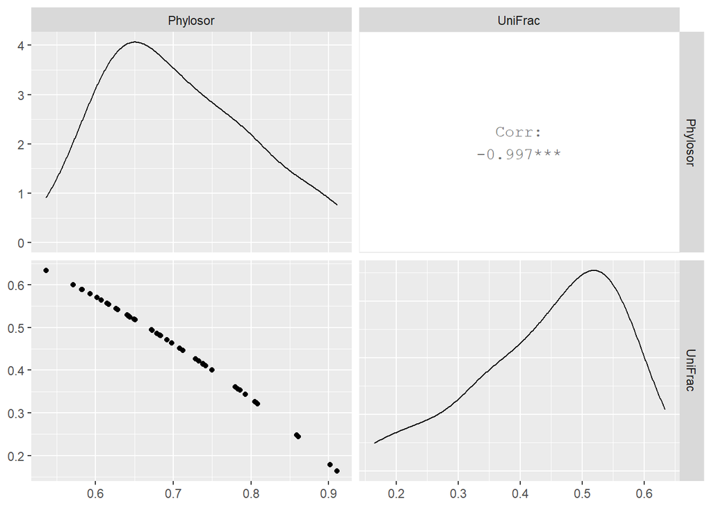

```r
# Vamos criar um data.frame com os resultados das métricas separados para as dimensões de riqueza e divergência.

metricas_riqueza_beta <- data.frame(Phylosor = as.numeric(resultados_Phylosor),
                       UniFrac = as.numeric(resultados_UniFrac))

# gráfico
library(GGally)
ggpairs(metricas_riqueza_beta, upper=list(continuous = wrap("cor", size = 4)))
```

Os valores de Phylosor e UniFrac apresenta 99% de correlação entre eles. Portanto, essas duas métricas identificam padrões identicos e não devem ser utilizadas simultaneamente.

Vamos avaliar a correlação entre os valores das métricas da diversidade beta filogénetica para a dimensão divergência.

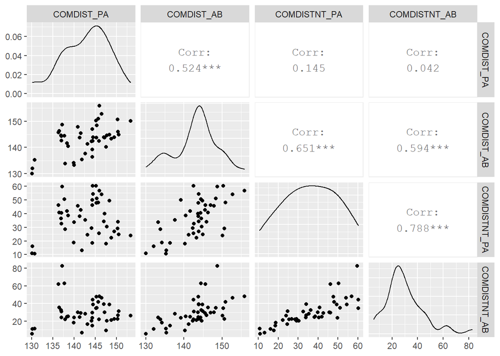

```r
# Vamos criar um data.frame com os resultados das métricas da dimensão divergência.
metricas_divergencia_beta <- data.frame(
                               COMDIST_PA = as.numeric(resultados_Comdist_PA),
                               COMDIST_AB = as.numeric(resultados_Comdist_AB),
                               COMDISTNT_PA = as.numeric(resultados_Comdistnt_PA),
                               COMDISTNT_AB = as.numeric(resultados_Comdistnt_AB))

# gráfico
library(GGally)
ggpairs(metricas_divergencia_beta, upper=list(continuous = wrap("cor", size = 4)))
```

Os valores das métricas de divergência filogenética beta apresentam correlações mais baixas do que as métricas da dimensão riqueza . Lembrem-se que COMDIST e COMDISTNT dão pesos diferentes para as relações de parentesco. COMDIST pesa as relações mais basais e internas da filogenia enquanto COMDISTNT pesa as relações nas partes terminais da filogenia. Portanto, elas podem trazer informações complementares.

#### Associação entre as métricas de diversidade beta filogenética e o gradiente de precipitação

Vamos avaliar e plotar a relação entre os valores de algumas métrica de diversidade beta filogenética (variável resposta) e os valores de precipitação (variável preditora).

#### Gráficos das métricas da dimensão divergência da diversidade beta filogenética

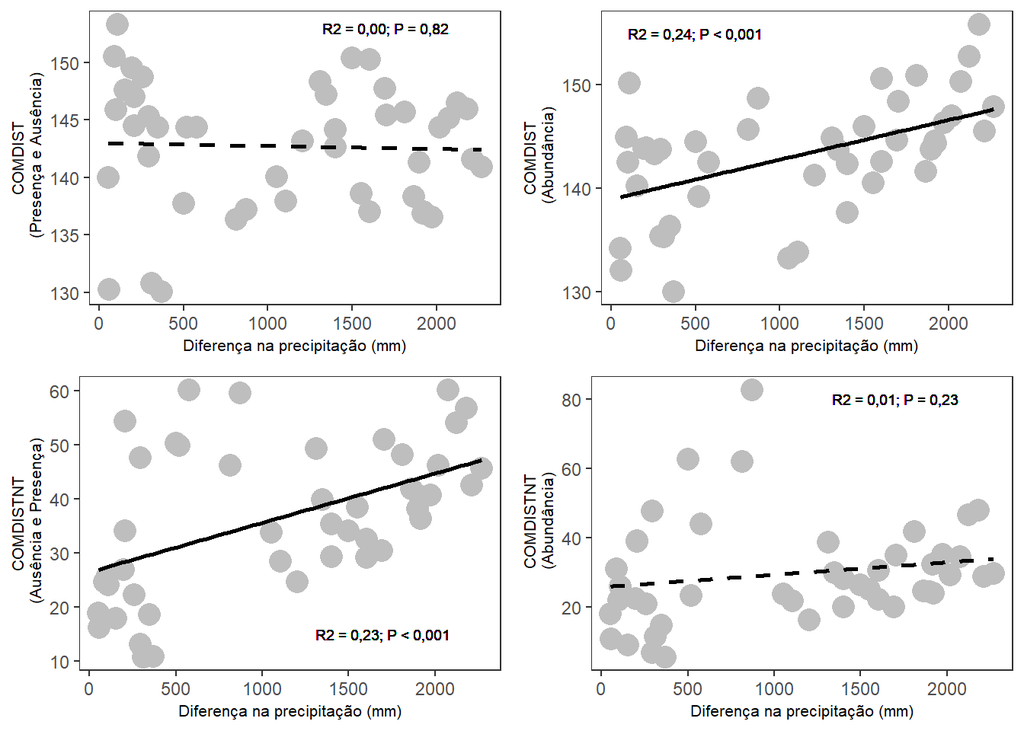

```r
# Planilha precipitação foi carregada na diversidade alfa filogenética
# Precisamos calcular a dissimilaridade par a par da preciítação entre s comunidades
library(vegan)
dis_prec <- vegdist(precipitacao, "euclidian")

# Vamos inserir estes dados na planilha metrica_divergencia_beta
metricas_divergencia_beta$dis_prec <- as.numeric(dis_prec)

# Gráficos
library(ggplot2)
library(ggpubr)
COMDIST_PA_plot <- ggplot(metricas_divergencia_beta, aes(dis_prec, COMDIST_PA)) +
        labs(x = "Diferença na precipitação (mm)",
             y = "COMDIST\n (Presença e Ausência)") +
        geom_point(size = 5, shape = 19, col = "gray") +
        theme_bw() +
        theme(panel.grid.major = element_blank(),
              panel.grid.minor = element_blank(),
              axis.title.y = element_text(size = 8),
               axis.title.x = element_text(size = 8)) +
        geom_smooth(method = lm, se = FALSE, color = "black", linetype="dashed") +
        geom_text(x = 1700, y = 153, label = "R2 = 0,00; P = 0,82",
                  color = "black", size = 2.5)
COMDIST_AB_plot <- ggplot(metricas_divergencia_beta, aes(dis_prec, COMDIST_AB)) +
        labs(x = "Diferença na precipitação (mm)",
             y = "COMDIST\n (Abundância)", size = 8) +
        geom_point(size = 5, shape = 19, col = "gray") +
        theme_bw() +
        theme(panel.grid.major = element_blank(),
              panel.grid.minor = element_blank(),
              axis.title.y = element_text(size = 8),
              axis.title.x = element_text(size = 8)) +
        geom_smooth(method = lm, se = FALSE, color = "black") +
        geom_text(x = 500, y = 155, label = "R2 = 0,24; P < 0,001",
                  color = "black", size = 2.5)
COMDISTNT_PA_plot <- ggplot(metricas_divergencia_beta, aes(dis_prec, COMDISTNT_PA)) +
        labs(x = "Diferença na precipitação (mm)",
             y = "COMDISTNT\n (Ausência e Presença)",
             size = 8) +
        geom_point(size = 5, shape = 19, col = "gray") +
        theme_bw() +
        theme(panel.grid.major = element_blank(),
              panel.grid.minor = element_blank(),
              axis.title.y = element_text(size = 8),
              axis.title.x = element_text(size = 8)) +
        geom_smooth(method = lm, se = FALSE, color = "black") +
        geom_text(x = 1700, y = 15, label = "R2 = 0,23; P < 0,001",
                  color = "black", size = 2.5)
COMDISTNT_AB_plot <- ggplot(metricas_divergencia_beta, aes(dis_prec, COMDISTNT_AB)) +
        labs(x = "Diferença na precipitação (mm)",
             y = " COMDISTNT\n (Abundância)",
             size = 8) +
        geom_point(size = 5, shape = 19, col = "gray") +
        theme_bw() +
        theme(panel.grid.major = element_blank(),
              panel.grid.minor = element_blank(),
              axis.title.y = element_text(size = 8),
              axis.title.x = element_text(size = 8)) +
        geom_smooth(method = lm, se = FALSE, color = "black", linetype="dashed") +
        geom_text(x = 1700, y = 80, label = "R2 = 0,01; P = 0,23",
                  color = "black", size = 2.5)
ggarrange(COMDIST_PA_plot, COMDIST_AB_plot, COMDISTNT_PA_plot,
          COMDISTNT_AB_plot, nrow = 2, ncol = 2)
```

#### Gráficos das métricas da dimensão riqueza da diversidade beta filogenética

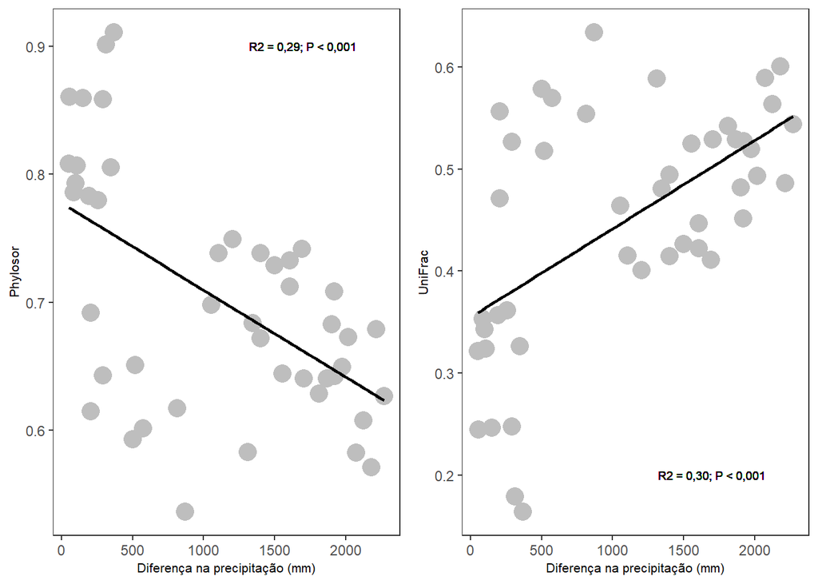

```r
# Vamos inserir os dados de precipitação na planilha metrica_riqueza_beta
metricas_riqueza_beta$dis_prec <- as.numeric(dis_prec)

# Gráficos
library(ggplot2)
library(ggpubr)
Phylosor_plot <- ggplot(metricas_riqueza_beta, aes(dis_prec, Phylosor)) +
        labs(x = "Diferença na precipitação (mm)",
             y = "Phylosor") +
        geom_point(size = 5, shape = 19, col = "gray") +
        theme_bw() +
        theme(panel.grid.major = element_blank(),
              panel.grid.minor = element_blank(),
              axis.title.y = element_text(size = 8),
               axis.title.x = element_text(size = 8)) +
        geom_smooth(method = lm, se = FALSE, color = "black") +
        geom_text(x = 1700, y =0.9, label = "R2 = 0,29; P < 0,001",
                  color = "black", size = 2.5)
UniFrac_plot <- ggplot(metricas_riqueza_beta, aes(dis_prec, UniFrac)) +
        labs(x = "Diferença na precipitação (mm)",
             y = "UniFrac", size = 8) +
        geom_point(size = 5, shape = 19, col = "gray") +
        theme_bw() +
        theme(panel.grid.major = element_blank(),
              panel.grid.minor = element_blank(),
              axis.title.y = element_text(size = 8),
              axis.title.x = element_text(size = 8)) +
        geom_smooth(method = lm, se = FALSE, color = "black") +
        geom_text(x = 1700, y = 0.2, label = "R2 = 0,30; P < 0,001",
                  color = "black", size = 2.5)
ggarrange(Phylosor_plot, UniFrac_plot, nrow = 1)
```

Phylosor e UniFrac foram relacionadas com o gradiente de precipitação. Comunidades com quantidade de precipitação parecidas abrigaram linhagens similares enquanto comunidades que recebem quantidade de precipitação diferentes abrigam linhagens mais distintas.

### Partição da diversidade beta filogenética

As métricas, Phylosor e UniFrac, podem ser parcionadas em dois componentes (Baselga 2010; Leprieur et al. 2012): i) subsituição de espécies entre as comunidades; e ii) aninhamento que representa a perda ou ganho de espécies entre comunidades atribuídos a diferença na riqueza de espécies. A partição da diversidade beta nestes componentes permite avaliar diferentes hipóteses sobre os processos e mecanismos atuando na montagem de comunidades.

Abaixo demonstramos os comandos no R para o cálculo da partição da diversidade beta filogenética utilizando os dados das comunidades de aves.

```r
# Dados já foram carregados no exemplo do MPD
# Pacote com a função para calcular a partição dos componentes do Phylosor
library(betapart)

# temos que transformar os dados para presença e ausência das espécies nas comunidades
library (vegan)
dados_PA <- decostand(composicao_especies, "pa")

# Partição dos componentes do Phylosor
resultados_Phylosor_particao <- phylo.beta.pair(dados_PA,
                                                filogenia_aves,
                                                index.family = "sorensen")
resultados_Phylosor_particao # mostra três matrizes: i) dissimilaridade total (phylo.beta.sor), ii) componente de substituição de espécies (phylo.beta.sim); e iii) componente aninhamento (phylo.beta.sne).
```

```
## $phylo.beta.sim
##             Com_1      Com_2      Com_3      Com_4      Com_5      Com_6
## Com_2  0.20376176
## Com_3  0.18252633 0.19791479
## Com_4  0.21535784 0.18090703 0.12912118
## Com_5  0.04160965 0.21624598 0.11244647 0.11673690
## Com_6  0.17045941 0.26884205 0.15338080 0.07652934 0.19051771
## Com_7  0.12764885 0.12475070 0.20925285 0.14420649 0.22531248 0.32972985
## Com_8  0.02562236 0.08736619 0.09784896 0.08808290 0.10773394 0.32954987
## Com_9  0.02582436 0.11319437 0.09862036 0.03715048 0.10858327 0.29912490
## Com_10 0.02900826 0.09891131 0.02430323 0.09972273 0.12197057 0.34879541
##             Com_7      Com_8      Com_9
## Com_2
## Com_3
## Com_4
## Com_5
## Com_6
## Com_7
## Com_8  0.27137232
## Com_9  0.22518018 0.09484536
## Com_10 0.23239937 0.02916368 0.08623080
##
## $phylo.beta.sne
##              Com_1       Com_2       Com_3       Com_4       Com_5       Com_6
## Com_2  0.010555419
## Com_3  0.012189799 0.022588797
## Com_4  0.001490113 0.012413621 0.011332588
## Com_5  0.099712393 0.091806260 0.079230545 0.090236464
## Com_6  0.157799231 0.148402851 0.148845810 0.173976150 0.071172466
## Com_7  0.130922706 0.142676636 0.107124026 0.126848648 0.036231389 0.027698466
## Com_8  0.291759967 0.284242023 0.257831752 0.271479830 0.179946338 0.077640387
## Com_9  0.295177382 0.279338070 0.260857680 0.290083917 0.183130032 0.083877427
## Com_10 0.344532363 0.330121559 0.333416782 0.317945617 0.228635920 0.114947055
##              Com_7       Com_8       Com_9
## Com_2
## Com_3
## Com_4
## Com_5
## Com_6
## Com_7
```

[output cut: 10 more lines]

```
## Com_6  0.32825864 0.41724490 0.30222661 0.25050549 0.26169018
## Com_7  0.25857156 0.26742733 0.31637687 0.27105514 0.26154387 0.35742832
## Com_8  0.31738233 0.37160822 0.35568071 0.35956273 0.28768028 0.40719026
## Com_9  0.32100174 0.39253244 0.35947804 0.32723440 0.29171330 0.38300233
## Com_10 0.37354062 0.42903287 0.35772001 0.41766834 0.35060649 0.46374247
##             Com_7      Com_8      Com_9
## Com_2
## Com_3
## Com_4
## Com_5
## Com_6
## Com_7
## Com_8  0.38531465
## Com_9  0.34931198 0.09839929
## Com_10 0.39840172 0.08933419 0.13928957
```

Vamos refazer a análise para UniFrac.

```r
# Partição dos componentes do UniFrac
resultados_UniFrac_particao <- phylo.beta.pair(dados_PA,
                                                filogenia_aves,
                                                index.family = "jaccard")
resultados_UniFrac_particao # mostra três matrizes: i) dissimilaridade total (phylo.beta.jac), ii) componente substituição de espécies (phylo.beta.jtu); e iii) componente aninhamento (phylo.beta.jne).
```

```
## $phylo.beta.jtu
##             Com_1      Com_2      Com_3      Com_4      Com_5      Com_6
## Com_2  0.33854167
## Com_3  0.30870573 0.33043216
## Com_4  0.35439413 0.30638657 0.22871094
## Com_5  0.07989490 0.35559580 0.20216068 0.20906787
## Com_6  0.29126923 0.42375967 0.26596733 0.14217790 0.32005859
## Com_7  0.22639823 0.22182818 0.34608618 0.25206375 0.36776329 0.49593510
## Com_8  0.04996451 0.16069323 0.17825578 0.16190477 0.19451230 0.49573150
## Com_9  0.05034850 0.20336856 0.17953493 0.07163952 0.19589556 0.46050214
## Com_10 0.05638100 0.18001690 0.04745319 0.18135976 0.21742205 0.51719543
##             Com_7      Com_8      Com_9
## Com_2
## Com_3
## Com_4
## Com_5
## Com_6
## Com_7
## Com_8  0.42689670
## Com_9  0.36758704 0.17325800
## Com_10 0.37714945 0.05667452 0.15877068
##
## $phylo.beta.jne
##              Com_1       Com_2       Com_3       Com_4       Com_5       Com_6
## Com_2  0.014442181
## Com_3  0.017256431 0.030899974
## Com_4  0.002015157 0.017617960 0.017601142
## Com_5  0.167751317 0.115413281 0.119532212 0.133894738
## Com_6  0.202999923 0.165051614 0.198201676 0.258468867 0.094766192
## Com_7  0.184498643 0.200172086 0.134592085 0.174440386 0.046877643 0.030690601
## Com_8  0.431873328 0.381164439 0.346470595 0.367034025 0.252307118 0.082996587
## Com_9  0.435648954 0.360399188 0.349312221 0.421467649 0.255773246 0.093368692
## Com_10 0.487528097 0.420435158 0.479489048 0.407873038 0.301761730 0.116443993
##              Com_7       Com_8       Com_9
## Com_2
## Com_3
## Com_4
## Com_5
## Com_6
## Com_7
```

[output cut: 10 more lines]

```
## Com_6  0.4942692 0.5888113 0.4641690 0.4006468 0.4148248
## Com_7  0.4108969 0.4220003 0.4806783 0.4265041 0.4146409 0.5266257
## Com_8  0.4818378 0.5418577 0.5247264 0.5289388 0.4468194 0.5787281 0.5562847
## Com_9  0.4859975 0.5637677 0.5288471 0.4931072 0.4516688 0.5538708 0.5177631
## Com_10 0.5439091 0.6004521 0.5269422 0.5892328 0.5191838 0.6336394 0.5697958
##            Com_8     Com_9
## Com_2
## Com_3
## Com_4
## Com_5
## Com_6
## Com_7
## Com_8
## Com_9  0.1791685
## Com_10 0.1640161 0.2445200
```

#### Gráficos com os resultados da partição da diversidade beta filogenética

Gráfico com os resultados dos componentes substituição e aninhamento da diversidade beta filogenética - Phylosor

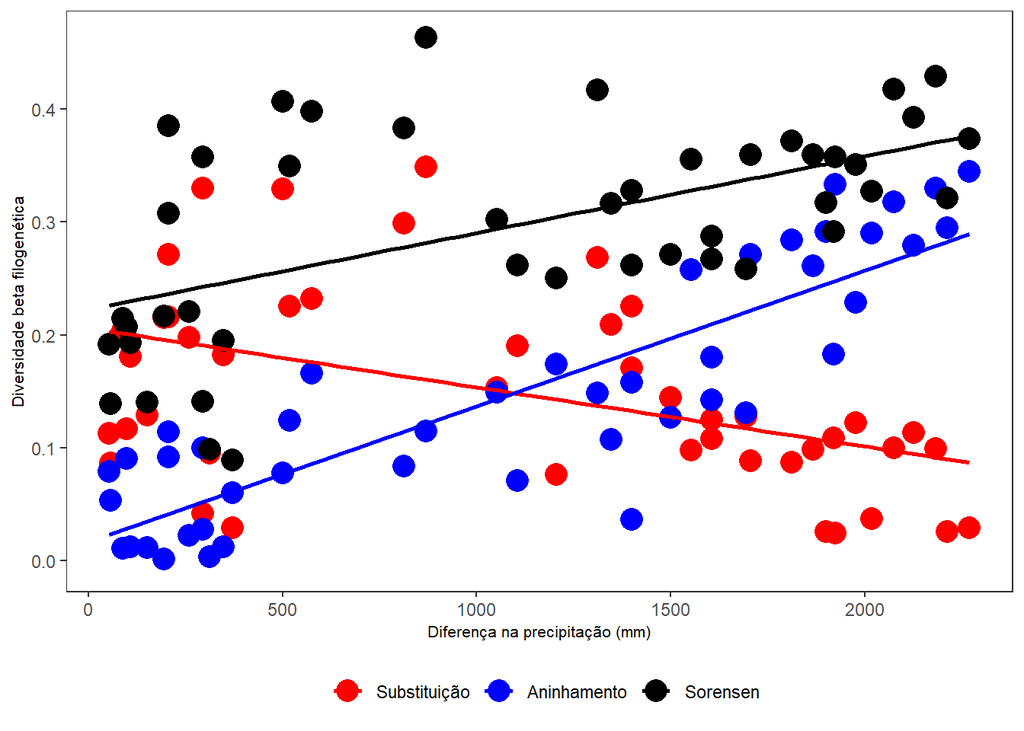

```r
# Vamos preparar os dados para o gráfico
particao_phylosor <- data.frame(
      substituicao = as.numeric(resultados_Phylosor_particao$phylo.beta.sim),
      aninhamento = as.numeric(resultados_Phylosor_particao$phylo.beta.sne),
      sorensen = as.numeric(resultados_Phylosor_particao$phylo.beta.sor),
      dis_prec = as.numeric(dis_prec))

library(reshape2)
dados_phylosor <- melt(particao_phylosor, id.vars="dis_prec")

# Gráficos
library(ggplot2)
ggplot(dados_phylosor, aes(dis_prec, value, col = variable)) +
        labs(x = "Diferença na precipitação (mm)",
             y = "Diversidade beta filogenética") +
        geom_point(size = 5, shape = 19) +
        scale_color_manual(labels = c("Substituição", "Aninhamento", "Sorensen"),
                           values = c("substituicao" = "red",
                                      "aninhamento" = "blue",
                                      "sorensen" = "black")) +
        theme_bw() +
        theme(panel.grid.major = element_blank(),
              panel.grid.minor = element_blank(),
              axis.title.y = element_text(size = 8),
               axis.title.x = element_text(size = 8),
              legend.position = "bottom",
              legend.title = element_blank()) +
        geom_smooth(method = lm, fill = NA) +
        geom_text(x = 1700, y =0.9, label = "R2 = 0,29; P < 0,001",
                  color = "black", size = 2.5)
```

Gráfico com os resultados dos componentes substituição e aninhamento da diversidade beta filogenética - UniFrac

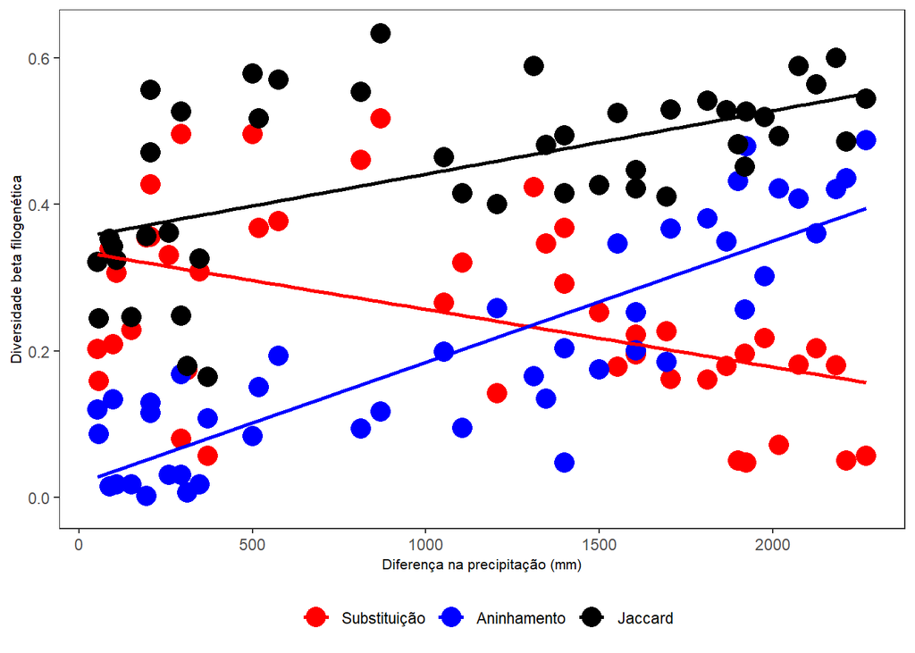

```r
# Vamos preparar os dados para o gráfico
particao_UniFrac <- data.frame(
        substituicao = as.numeric(resultados_UniFrac_particao$phylo.beta.jtu),
        aninhamento = as.numeric(resultados_UniFrac_particao$phylo.beta.jne),
        jaccard = as.numeric(resultados_UniFrac_particao$phylo.beta.jac),
        dis_prec = as.numeric(dis_prec))

library(reshape2)
dados_unifrac <- melt(particao_UniFrac, id.vars="dis_prec")

# Gráficos
library(ggplot2)
ggplot(dados_unifrac, aes(dis_prec, value, col = variable)) +
        labs(x = "Diferença na precipitação (mm)",
             y = "Diversidade beta filogenética") +
        geom_point(size = 5, shape = 19) +
        scale_color_manual(labels = c("Substituição", "Aninhamento", "Jaccard"),
                           values = c("substituicao" = "red",
                                      "aninhamento" = "blue",
                                      "jaccard" = "black")) +
        theme_bw() +
        theme(panel.grid.major = element_blank(),
              panel.grid.minor = element_blank(),
              axis.title.y = element_text(size = 8),
               axis.title.x = element_text(size = 8),
              legend.position = "bottom",
              legend.title = element_blank()) +
        geom_smooth(method = lm, fill = NA) +
        geom_text(x = 1700, y =0.9, label = "R2 = 0,29; P < 0,001",
                  color = "black", size = 2.5)
```

## Modelos Nulos

Em muitos casos os valores de diversidade filogenética são correlacionados com a riqueza de espécies nas comunidades. Por exemplo, se um pesquisador relata que duas comunidades apresentam diferentes valores de PD, é impossível saber se esta diferença é simplesmente porque elas tem diferentes valores de riqueza de espécies ou se há algum fator fundamental sobre a informação filogenética que é importante. Outra questão abordada nos estudos de montagem das comunidades é saber se os valores observados para as métricas (e.g. MPD ou MNTD) relacionadas com a estrutura filogenética das comunidades seriam diferentes se a colonização das espécies do pool regional fosse aleatória? Os modelos nulos respondem estas perguntas.

Os modelos nulos são construídos considerando processos ecológicos ou evolutivos de interesse. Eles geram padrões que são baseados na aleatorização dos dados ecológicos ou amostragens aleatórias de uma distribuição conhecida ou hipótetica (Gotelli & Graves 1996). Neste caso, alguns elementos dos dados são mantidos constantes, e outros são permitidos variar estocasticamente para criar novos padrões. O principal motivo para a construção de modelos nulos é produzir um padrão que seria esperado na ausência de um mecanismo ecológico específico (Gotelli & Graves 1996). Contudo, ressaltamos que os modelos nulos podem revelar padrões não comuns, mas eles não podem determinar os mecanismos responsáveis por gerar estes padrões (Gotelli & Graves 1996).

Os modelos nulos empregados para contrapor os padrões observados pelas métricas de diversidade filogenética utilizam a aleatorização dos dados de duas formas principais: i) aleatorizando o nome das espécies na árvore filogenética mantendo a estrutura e composição da matriz de co-ocorrência das espécies e o comprimento dos ramos da árvore inalterados; e ii) aleatorizando as linhas e/ou colunas da matriz de co-ocorrência das espécies (Gotelli 2000; Ulrich & Gotelli 2010). De forma geral, nas análises de diversidade filogenética as aleatorizações são repetidas 999 vezes (pode ser mais ou menos a critério do pesquisador) e calcula-se a média e o desvio padrão dos valores gerados pelo modelos. Com estes dados, calcula-se o tamanho do efeito padronizado (do inglês Standardized Effect Size - SES) utilizando a seguinte fórmula:

> SES = (Valor Observado - Média dos valores gerados na aleatorização)/ Desvio Padrão dos valores gerados na aleatorização

Os valores de SES são utilizados para rejeitar ou não a hipótese nula que o padrão observado é diferente do esperado pelo acaso. Contudo, tenha em mente que a definição do esquema de aleatorização dos modelos nulos não é meramente uma questão técnica (Gotzenberger et al. 2012). A definição do esquema de aleatorização irá determinar quais os mecanismos ecológicos são permitidos ou excluídos no modelo nulo (Gotzenberger et al. 2012). Consequentemente, ele estará avaliando diferentes hipóteses nulas.

Abaixo demonstramos os comando no R para calcular os modelos nulos para as métricas de diversidade filogenética.

#### Nearest Relative Index (NRI) ou Standardized Effect Size of MPD (Webb et al. 2008)

Esta métrica calcula o tamanho do efeito padronizado para a métrica MPD. Contudo, NRI é calculado multiplicando os resultados do SES por -1. Valores positivos de NRI indicam agrupamento filogenético e valores negativos de NRI indicam dispersão filogenética.

```r
# NRI ou SES_MPD
resultados_SES_MPD <- ses.mpd(composicao_especies, cophenetic(filogenia_aves),
                              null.model = "taxa.labels",
                              abundance.weighted = FALSE,
                              runs = 999)
resultados_SES_MPD # mostra a riqueza de espéices,MPD observado, média e desvio padrão dos valores de MPD das aleatorizações, SES e o valor de p.
```

```
##        ntaxa  mpd.obs mpd.rand.mean mpd.rand.sd mpd.obs.rank   mpd.obs.z
## Com_1     27 150.7914      153.9628    4.031223          219 -0.78671109
## Com_2     26 157.3158      153.8707    4.249372          764  0.81074403
## Com_3     25 146.1622      153.8529    4.695578           73 -1.63787060
## Com_4     25 154.5005      153.7073    4.711193          517  0.16835228
## Com_5     22 143.0727      153.5994    5.602894           39 -1.87878993
## Com_6     18 141.1926      153.8348    6.894796           39 -1.83358210
## Com_7     15 154.3145      153.5433    8.098484          510  0.09522946
## Com_8     12 141.4292      154.2466    9.941578           92 -1.28927239
## Com_9     13 139.6198      154.0045    9.384975           70 -1.53273360
## Com_10     9 143.0862      154.2842   12.095209          171 -0.92581539
##        mpd.obs.p runs
## Com_1      0.219  999
## Com_2      0.764  999
## Com_3      0.073  999
## Com_4      0.517  999
## Com_5      0.039  999
## Com_6      0.039  999
## Com_7      0.510  999
## Com_8      0.092  999
## Com_9      0.070  999
## Com_10     0.171  999
```

Veja a ajuda deste comando usando`?ses.mpd` para ver todas as possibilidades de modelos nulos disponíveis.

#### Nearest Taxon Index (NTI) ou Standardized Effect Size of MNTD (Webb et al. 2008)

Esta métrica calcula o tamanho do efeito padronizado para a métrica MNTD. Contudo, NTI é calculado multiplicando os resultados do SES por -1. Valores positivos de NTI indicam agrupamento filogenético e valores negativos de NTI indicam dispersão filogenética.

```r
# NTI ou SES_MNTD
resultados_SES_MNTD <- ses.mntd(composicao_especies, cophenetic(filogenia_aves),
                              null.model = "taxa.labels",
                              abundance.weighted = FALSE,
                              runs = 999)
resultados_SES_MNTD # mostra a riqueza de espéices,MNTD observado, média e desvio padrão dos valores de MNTD das aleatorizações, SES e o valor de p.
```

```
##        ntaxa  mntd.obs mntd.rand.mean mntd.rand.sd mntd.obs.rank  mntd.obs.z
## Com_1     27  63.89727       63.47541     6.750213           513  0.06249601
## Com_2     26  66.15828       64.53002     7.576848           577  0.21489892
## Com_3     25  72.96912       66.02743     7.631865           805  0.90956637
## Com_4     25  67.67170       65.96463     7.920100           571  0.21553680
## Com_5     22  64.93477       70.13035     9.368085           297 -0.55460358
## Com_6     18  63.72337       76.49912    11.344195           133 -1.12619236
## Com_7     15  93.54980       83.49955    13.970657           770  0.71938289
## Com_8     12  78.24876       91.47839    16.694152           223 -0.79247081
## Com_9     13  62.34565       88.19861    15.412315            51 -1.67742228
## Com_10     9 112.23127      101.20222    20.579268           709  0.53593008
##        mntd.obs.p runs
## Com_1       0.513  999
## Com_2       0.577  999
## Com_3       0.805  999
## Com_4       0.571  999
## Com_5       0.297  999
## Com_6       0.133  999
## Com_7       0.770  999
## Com_8       0.223  999
## Com_9       0.051  999
## Com_10      0.709  999
```

#### Standardized Effect Size of PD (Webb et al. 2008)

Esta métrica calcula o tamanho do efeito padronizado para a métrica PD.

```r
# SES_PD
resultados_SES_PD <- ses.pd(composicao_especies, filogenia_aves,
                              null.model = "independentswap",
                              runs = 999)
resultados_SES_PD # mostra a riqueza de espéices,MNTD observado, média e desvio padrão dos valores de PD das aleatorizações, SES e o valor de p.
```

```
##        ntaxa    pd.obs pd.rand.mean pd.rand.sd pd.obs.rank   pd.obs.z pd.obs.p
## Com_1     27 1259.3151    1272.8921   64.31142         412 -0.2111142    0.412
## Com_2     26 1293.1521    1233.9548   68.52980         807  0.8638186    0.807
## Com_3     25 1222.3102    1202.8900   67.62350         610  0.2871807    0.610
## Com_4     25 1254.5410    1201.7759   66.06990         774  0.7986252    0.774
## Com_5     22 1021.9670    1096.3573   67.32626         146 -1.1049224    0.146
## Com_6     18  856.7810     949.9951   68.67069          86 -1.3574065    0.086
## Com_7     15  930.6452     840.7064   64.06589         915  1.4038486    0.915
## Com_8     12  678.9394     708.7423   60.26984         298 -0.4944900    0.298
## Com_9     13  673.6288     751.7893   61.72338         105 -1.2663031    0.105
## Com_10     9  599.6924     575.9467   58.13567         659  0.4084523    0.659
##        runs
## Com_1   999
## Com_2   999
## Com_3   999
## Com_4   999
## Com_5   999
## Com_6   999
## Com_7   999
## Com_8   999
## Com_9   999
## Com_10  999
```

#### Standardized Effect Size of Phylosor

Não há pacotes que calculam o SES para a métrica Phylosor. Assim, iremos usar o comando `phylosor.rnd()`para criar modelos nulos para o Physolor, e em seguida, iremos usar uma função para calcular os valores de SES e os valores de P.

```r
# Modelo nulo que rearranja o nome das espécies na filogenia

modelos_nulo <- phylosor.rnd(composicao_especies, filogenia_aves,
                             null.model = "taxa.labels", runs = 9)

# Função para calcular o SES eo valor de P
ses.physo <- function(obs, nulo_phylosor){
  nulo_phylosor <- t(as.data.frame(lapply
            (nulo_phylosor, as.vector)))
  physo.obs <- as.numeric(obs)
  physo.mean <- apply(nulo_phylosor, MARGIN = 2,
    FUN = mean, na.rm = TRUE)
  physo.sd <- apply(nulo_phylosor, MARGIN = 2,
    FUN = sd, na.rm = TRUE)
  physo.ses <- (physo.obs - physo.mean)/physo.sd
  physo.obs.rank <- apply(X = rbind(physo.obs,
        nulo_phylosor), MARGIN = 2,
        FUN = rank)[1, ]
  physo.obs.rank <- ifelse(is.na(physo.mean), NA,
                physo.obs.rank)
  data.frame(physo.obs, physo.mean, physo.sd,
        physo.obs.rank, physo.ses,
        physo.obs.p = physo.obs.rank/
        (dim(nulo_phylosor)[1] + 1))
}

ses.physo (resultados_Phylosor, modelos_nulo)
```

```
##    physo.obs physo.mean   physo.sd physo.obs.rank   physo.ses physo.obs.p
## 1  0.7856828  0.8052378 0.03921419              4 -0.49867045         0.4
## 2  0.8052839  0.8758607 0.02939490              1 -2.40098850         0.1
## 3  0.7831520  0.8313609 0.02616258              2 -1.84266486         0.2
## 4  0.8586780  0.8652646 0.02841978              5 -0.23176206         0.5
## 5  0.6717414  0.7366012 0.02916292              1 -2.22405165         0.1
## 6  0.7414284  0.7117505 0.03371290              9  0.88031307         0.9
## 7  0.6826177  0.7054992 0.03130273              3 -0.73097644         0.3
## 8  0.6789983  0.7361949 0.03555085              1 -1.60886724         0.1
## 9  0.6264594  0.6126798 0.02024673              8  0.68058504         0.8
## 10 0.7794964  0.7754073 0.03130397              7  0.13062651         0.7
## 11 0.8066793  0.8121336 0.03766460              4 -0.14481125         0.4
## 12 0.6919478  0.7684458 0.05629381              2 -1.35890698         0.2
## 13 0.5827551  0.6674813 0.05015634              1 -1.68924241         0.1
## 14 0.7325727  0.7462542 0.04106106              3 -0.33319996         0.3
```

[output cut: 31 more lines]

### Para se aprofundar

- Recomendamos aos interessados os livros: i) Swenson (2014) Functional and Phylogenetic Ecology in R; ii) Paradis (2012) Analysis of Phylogenetics and Evolution in R; iii) Cadotte & Davies (2016) Phylogenies in Ecology, iv) Gotelli & Graves (2006) Null Models in Ecology; e v) Magurran & McGill (2010) - Biological Diversity Frontiers in Measurement and Assessment.